# Multivariable Regression - Adjustment

## Consider the Following Simulated Data

Code for the first plot, rest omitted (See the git repo for the rest of the code.)

```
n <- 100
t <- rep(c(0,1), c(n/2,n/2))
x <- c(runif(n/2),runif(n/2))
beta0 <- 0
beta1 <- 2
tau <- 1
sigma <- .2
y <- beta0 + x * beta1 + t * tau + rnorm(n, sd=sigma)
plot(x, y, type="n", frame=F)
abline(lm(y ~ x), lwd=2)
abline(h=mean(y[1:(n/2)]), lwd=3)
abline(h=mean(y[(n/2 + 1):n]), lwd=3)
fit <- lm(y ~ x + t)
abline(coef(fit)[1], coef(fit)[2], lwd=3)
abline(coef(fit)[1] + coef(fit)[3], coef(fit)[2], lwd=3)
points(x[1:(n/2)], y[1:(n/2)], pch=21, col="black", bg="lightblue", cex=2)
points(x[(n/2 + 1):n], y[(n/2 + 1):n], pch=21, col="black", bg="salmon", cex=2)
```

## Simulation 1

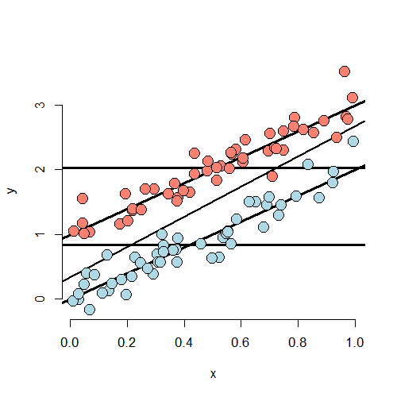

## Discussion

#### Some things to note in this simulation

- The $X$ variable is unrelated to the group status
- The $X$ variable is related to $Y$, but the intercept depends on group status
- The group variable is related to $Y$
  - The relationship between group status and $Y$ is constant depending on $X$
  - The relationship between group and $Y$ disregarding $X$ is about the same as holding $X$ constant

## Simulation 2

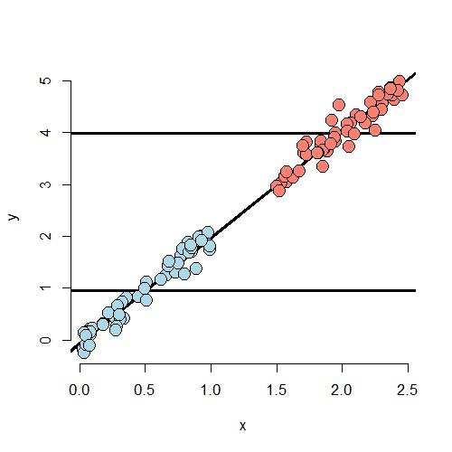

## Discussion

#### Some things to note about this simulation

- The $X$ variable is highly related to group status
- The $X$ variable is related to $Y$, the intercept doesn’t depend on the group variable
  - The $X$ variable remains related to $Y$ holding group status constant
- The group variable is marginally related to $Y$ disregarding $X$
- The model would estimate no adjusted effect due to group
  - There isn’t any data to inform the relationship between group and $Y$
  - This conclusion is entirely based on the model

## Simulation 3

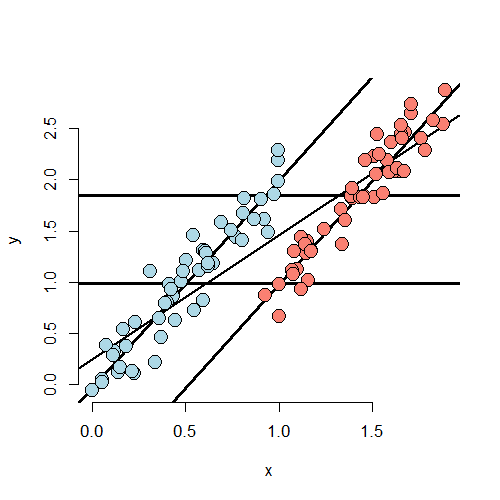

## Discussion

#### Some things to note in this simulation

- Marginal association has red group higher than blue
- Adjusted relationship has blue group higher than red
- Group status related to $X$
- There is some direct evidence for comparing red and blue holding $X$ fixed

## Simulation 4

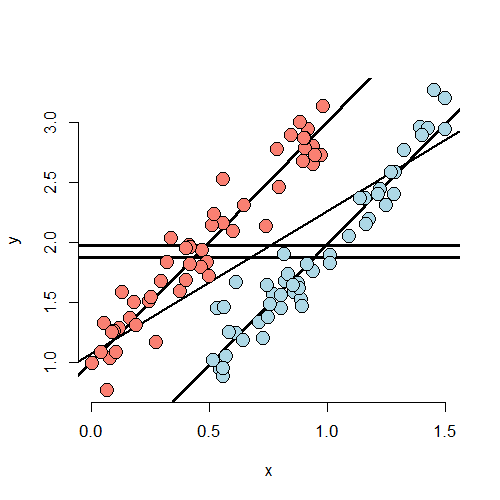

## Simulation 5

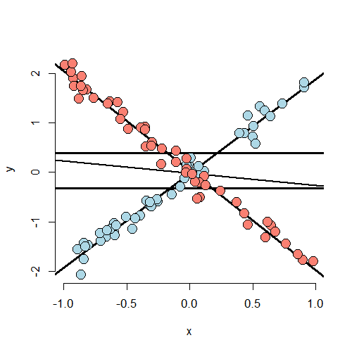

## Discussion

#### Some things to note from this simulation

- There is no such thing as a group effect here
  - The impact of group reverses itself depending on $X$
  - Both intercept and slope depend on group
- Group status and $X$ unrelated
  - There’s lots of information about group effects holding $X$ fixed

## Simulation 6

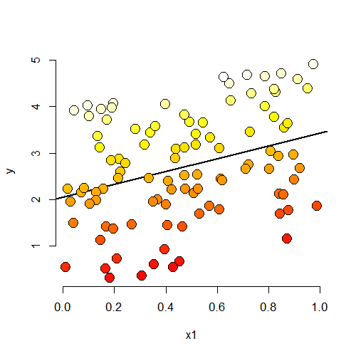

## Do This to Investigate the Bivariate Relationship

```r
library(rgl)
plot3d(x1, x2, y)
```

## Residual Relationship

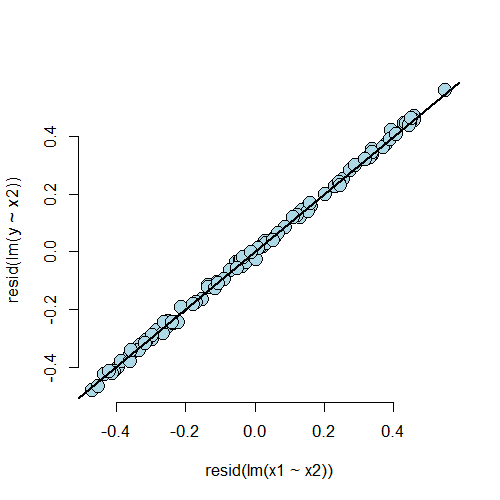

## Some Final Thoughts

- Modeling multivariate relationships is difficult
- Play around with simulations to see how the inclusion or exclusion of another variable can change analyses
- The results of these analyses deal with the impact of variables on associations
  - Ascertaining mechanisms or cause are difficult subjects to be added on top of difficulty in understanding multivariate associations